# van Zyl et al., 2026; water uptake

This study aims to identify drivers of inter-specific differences in water uptake patterns for a diverse set of species. To achieve this, δ¹⁸O values of water from various soil depths were compared with the δ¹⁸O of water extracted from twigs of the same individuals, allowing for the evaluation of species-specific patterns of water uptake. By combining various indicators, including tolerance indices derived from climatic data of their native distributions, soil moisture, drought tolerance related to the water availability at a finer scale, fine-scale hydrological traits and the resource demands of species, it further aims to reflect different species-specific adaptive strategies to drought. Due to the experiment having such a diversity of species which differ greatly in size, height was also included as a potential driver of water uptake depths.

```r
prelim_dir <- file.path("results", "data", "raw")
data_dir <- file.path("results", "data", "processed")
scripts_dir <- file.path("results", "scripts")
suppl_dir <- file.path("text", "supplementary")
figs_dir <- file.path("text", "figures")
tabs_dir <- file.path("text", "tables")
```

# Install required packages and load libraries

```r
required_packages <- c(
  "readxl", "dplyr", "tidyr", "ggplot2",
  "forcats", "factoextra", "nlme",
  "missForest", "rfPermute",
  "ranger", "pdp", "purrr", "iml",
  "ggcorrplot", "psych", "reshape2"
)
invisible(lapply(required_packages, library, character.only = TRUE))
```

```
## Welcome to factoextra!
```

```
## Want to learn more? See two factoextra-related books at https://www.datanovia.com/en/product/practical-guide-to-principal-component-methods-in-r/
```

```
## Welcome to rfPermute v2.5.5
## See rfPermuteTutorial() for a guide to the package.
```

# Data preparations

In order to perform the analyses for the final results of the manuscript, data from several sources were combined. Many of the variables in the final data set were simply extracted from the raw data, while others needed to be calculated or required processing of the raw data. For the latter, the steps required to prepare the data for analysis are described in the following sections.

## Calculate f<sub>shallow</sub> (fraction of water uptake from shallow soil) and f<sub>deep</sub> (fraction of water uptake from deep soil) for each tree, using δ18O from twigs and soil water

To get a more accurate indicator of source water and to account for species getting water from more than just one source, a two-end member mixing model was performed. The conceptual model assumes that each tree’s δ18O<sub>twig</sub> is a mixture of two soil water sources; shallow water and deep water. For this study, shallow water was defined as source water found within the top 20 cm below ground (0 - 20 cm), whilst deep water refers to water below 20 cm underground (>20cm). Only the δ18O<sub>soil</sub> from the final two sampling dates (30.06 and 04.08.2025) were used in the model, as they were closest to the dates of the twig sampling. Therefore, δ18O<sub>deep</sub> was calculated as the mean δ18O<sub>soil</sub> across the two sampling dates, across all three locations, for depths over 20cm (50, 100, 150, 200, and 250 cm below ground), whilst δ18O<sub>shallow</sub> refers to the mean δ18O<sub>soil</sub> across the two sampling dates, across all three locations, for depths of 0 - 20 cm (10, 20 cm below ground). This model was applied to each tree and the values were constrained to be between zero and one [0:1]. This model, therefore, shows what fraction of the source water of different trees is coming from deep and shallow soils.

```r
#upload isotope results for twigs
twigs <- read.csv(file.path(prelim_dir, "d18O_extracted_water_twigs.csv"))
twigs <- twigs %>%
  select("block", "species_code", "d18O")
colnames(twigs)[3] <- "twig_d18O"

#upload soil water data
#Soil water - d18O
soil <- read.csv(file.path(prelim_dir, "d18O_extracted_water_soil.csv"))

#two end member mixing model - average of soil water d18O from 30.06 and 04.08
soil_endmembers_3 <- soil %>%
  dplyr::filter(sampling_date %in% c("30.06.2025", "04.08.2025")) %>%
  dplyr::mutate(Source = ifelse(depth <= 20, "Shallow", "Deep"))

soil_endmembers_3 <- soil_endmembers_3 %>%
  dplyr::group_by(Source) %>%
  dplyr::summarise(
    mean_d18O = mean(d18O, na.rm = TRUE),
    sd_d18O   = sd(d18O, na.rm = TRUE),
    n         = dplyr::n(),
    .groups = "drop"
  )

d18O_shallow_3 <- soil_endmembers_3$mean_d18O[soil_endmembers_3$Source == "Shallow"]
d18O_deep_3    <- soil_endmembers_3$mean_d18O[soil_endmembers_3$Source == "Deep"]

twigs_mix_3 <- twigs %>%
  mutate(
    f_shallow = (twig_d18O - d18O_deep_3) / (d18O_shallow_3 - d18O_deep_3),
    f_deep    = 1 - f_shallow
  )

#constrain to 0,1 where f_shallow=1 is mostly shallow water and f_shallow=0 is mostly deep water
twigs_mix_3 <- twigs_mix_3 %>%
  mutate(
    f_shallow = pmin(pmax(f_shallow, 0), 1),
    f_deep    = 1 - f_shallow,
    species_code   = factor(twigs_mix_3$species_code, levels = sort(unique(twigs_mix_3$species_code))))

twigs_mix_3 <- twigs_mix_3 %>%
  mutate(
    f_shallow = pmin(pmax(f_shallow, 0), 1),
    f_deep    = 1 - f_shallow,
    species_code   = factor(as.character(species_code))  # resets levels alphabetically
  )

#remove NAs
twigs_mix_3 <- twigs_mix_3 %>%
  filter(!is.na(f_shallow) & !is.na(f_deep))
```

In order to distinguish between angiosperms and gymnosperms for Figure 1 (below), information on the clade of each species was added to the twigs_mix_3 data frame

```r
#upload clade data
clade<-read.csv(file.path(prelim_dir,"clade.csv"))
#select columns we need
clade_subset <- clade %>%
  select("block","species_code", "clade")
#merge clade_subset with twigs_mix_3 by block and species_code
twigs_mix_3 <- left_join(twigs_mix_3, clade_subset, by =c("block", "species_code"))
#for block=C, species_code = sor auc, clade= NA - change to A
twigs_mix_3$clade[twigs_mix_3$species_code == "Sal fra" & twigs_mix_3$block == "C"] <- "A"
```

## Calculate the predicted rooting depth for each species

To quantify the relationship between tree height and rooting depth, we fitted a linear mixed-effects model with rooting depth as the response variable and tree height as a fixed effect. Species was included as a random effect, allowing both intercepts and the effect of tree height (i.e., slopes) to vary among species. To develop the predictive model, rooting depth data was primarily obtained from the online database of Kutschera & Lichtenegger (2002). For 12 species lacking data, additional information was sourced from the RSIP (Root Systems of Individual Plants) database from Tumber-Dávila et al. (2022).

```r
#upload rooting depth data compiled from the Kutschera and Lichtenegger (2002) database, Wageningen University and the RSIP database
roots2 <- read.csv(file.path(prelim_dir, "root_depth.csv"))
mod2<-lme(root_depth_cm ~ height_plant_cm,
          random = ~ height_plant_cm| species,
          data = roots2,
          na.action = na.omit)

#predict for model 2
pred_10_mod2 <- predict(
  mod2,
  newdata = data.frame(
    height_plant_cm = 10,
    species = unique(roots2$species)
  )
)
#tidy table
root_data <- expand.grid(
  height_plant_cm = 10,
  species = unique(roots2$species)
)
root_data$pred_root_depth <- predict(mod2, root_data)
root_data <- root_data %>%
  select(species, pred_root_depth)
```

## Calculate the slow-fast PC1 axis for each species

A principal component analysis (PCA) was performed using seven different functional traits expected to be important in predicting growth response. Several of the traits were measured directly from the trees in ARBOfun (specific leaf area (SLA), leaf nitrogen content (LNC), carbon to nitrogen ratio (C:N) and stomatal density). These trait measurements were obtained for individual trees and subsequently aggregated to the species level by calculating the mean value across all individuals sampled for each species. These species-specific mean trait values were then used in subsequent analyses. In addition to the measured traits, additional traits (wood density, stomatal conductance and A<sub>max</sub> (maximum photosynthetic assimilation rate, a measure for the photosynthetic capacity)) were taken from the gap-filled TRY data from Kretz et al. (2025).

```r
#upload the TRY gap filled data from Kretz et al. 2025 - species-level data - species former names
TRY<-read.csv(file.path(prelim_dir,"TRY_gap_filled_data.csv"))
#Upload the measured traits data from ARBOfun- this data comes from already published data (see metadata) - new names
#SLA, leaf_N, leaf_CN
Kretz<-read.csv(file.path(prelim_dir,"Kretz_et_al_2026.csv"))
Kretz<-Kretz %>%
  select(species, species_former_name, block_ID, SLA, leaf_N, leaf_CN)
colnames(Kretz)[3]<-"block"

##Stomatal density
#data for angiosperms - contains the new species names/nomenclature
Sachsenmaier_angiosperms<-read.csv(file.path(prelim_dir,"Sachsenmaier_angiosperms.csv"))
Sachsenmaier_angiosperms<-Sachsenmaier_angiosperms %>%
  select(species, block, SD)
#calculate mean SD for each individual/replicate
Sachsenmaier_angiosperms_mean <- Sachsenmaier_angiosperms %>%
  dplyr::group_by(species, block) %>%
  dplyr::summarise(
    SD = mean(SD, na.rm = TRUE),
    .groups = "drop"
  )

#Gymnosperms data uses old names/nomenclature, however, no names changed for the species measured, so the old names = new names
Sachsenmaier_gymno<-read.csv(file.path(prelim_dir,"Sachsenmaier_gymnosperms.csv"))
Sachsenmaier_gymno<-Sachsenmaier_gymno %>%
  select(species, tree_id, SD_sbs)
colnames(Sachsenmaier_gymno)[1]<-"species_former_name"
#calculate mean SD_sbs per tree_id
Sachsenmaier_gymno<-Sachsenmaier_gymno %>%
  dplyr::group_by(tree_id) %>%
  dplyr::summarise(mean_SD_sbs = mean(SD_sbs, na.rm = TRUE))

#the published data set used contain tree_id, however, we want to have the species and block combination - thus we need a dataframe containing both:
gymno<-read.csv(file.path(prelim_dir,"gymno.csv"))

#join Sachsenmaier_gymno with gymno by tree_id
gymno_Sachsenmaier<-left_join(Sachsenmaier_gymno, gymno, by = "tree_id")
#some individuals have NAs because not VITs- manually edit

gymno_Sachsenmaier<-gymno_Sachsenmaier %>%
  select(mean_SD_sbs, block, species)
colnames(gymno_Sachsenmaier)[1]<-"SD"
#new names

#combine gymno_Sachsenmaier and Sachsenmaier_angiosperms (new names)
Sachsenmaier_combined<-rbind(gymno_Sachsenmaier, Sachsenmaier_angiosperms_mean)
#121 - uses NEW names

#join Sachsenmaier_combined to Kretz, by species, block
result <- Sachsenmaier_combined %>%
  left_join(
    Kretz,
    by = c("species", "block")
  )
colnames(result)[1]<-"SD_sbs_mean"

#calculate mean per species
result<-result %>%
  dplyr::group_by(species, species_former_name) %>%
  dplyr::summarise(
    mean_SLA = mean(SLA, na.rm = TRUE),
    mean_leaf_N = mean(leaf_N, na.rm = TRUE),
    mean_leaf_CN = mean(leaf_CN, na.rm = TRUE),
    mean_SD_sbs_mean = mean(SD_sbs_mean, na.rm = TRUE),
    .groups = "drop_last"
  )

LES<-left_join(result, TRY, by = "species_former_name")

#gap filling
library(missForest)
# Exclude the species and species_former_name columns for imputation
x <- as.data.frame(LES[,c(-1,-2)])

imp_LES <- missForest(
  x,
  maxiter=100,
  ntree=2500)
imputed_data_LES <- imp_LES$ximp
pca<-prcomp(imputed_data_LES, center = TRUE, scale. = TRUE)
PC1_scores<-pca$x[,1]
PC1_scores_df<-data.frame(species = LES$species, PC1_scores = PC1_scores)
write.csv(PC1_scores_df, file.path(data_dir, "PC1_scores.csv"), row.names = FALSE)
#
```

Missing trait values for species (4.7% of the total data) were imputed using a random forest–based imputation approach implemented in the “missForest”package (Stekhoven, 2025):

```r
# Original data used for imputation (excluding species column)
# Calculate number and percentage of missing values
LES_traits <- LES[,c(-1,-2)]  # Exclude the species and species_former_name columns for imputation
n_missing <- sum(is.na(LES_traits))
n_total <- nrow(LES_traits) * ncol(LES_traits)

percent_missing <- (n_missing / n_total) * 100

percent_missing
```

```
## [1] 4.761905
```

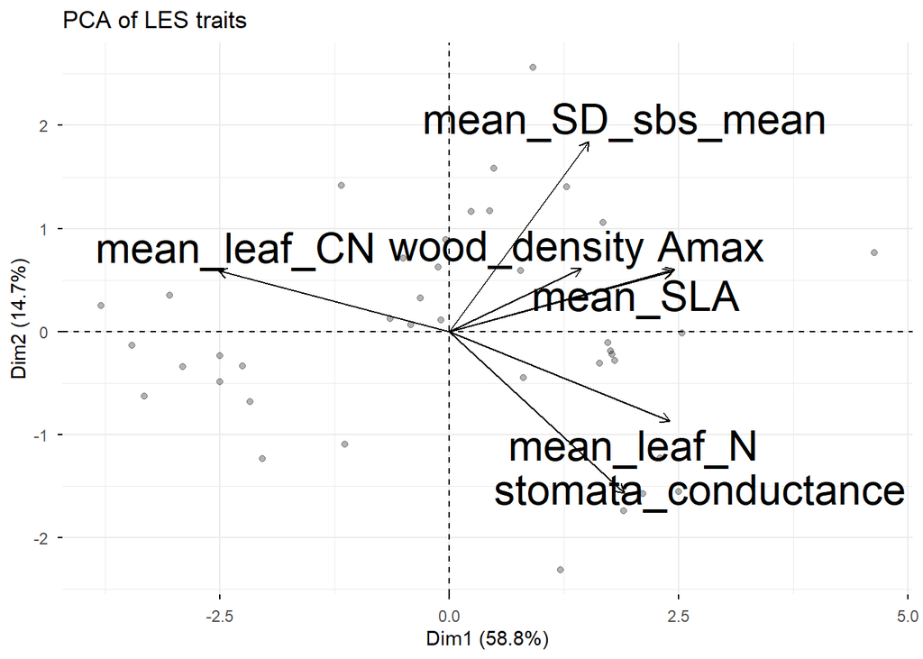

```r
pca<-prcomp(imputed_data_LES[,c("mean_SLA", "mean_leaf_N", "mean_leaf_CN", "mean_SD_sbs_mean", "Amax", "stomata_conductance", "wood_density")], center = TRUE, scale. = TRUE)

library(factoextra)
fviz_pca_biplot(pca,
                repel = TRUE,
                geom.ind = "point",
                alpha.ind = 0.3,
                label = "var",
                labelsize = 8,
                col.var = "black",
                title = "PCA of LES traits")
```

The outputs of the data processing steps described above were combined with other predictors to create a final dataset for the analyses. The final dataset was exported as a CSV file, which is used in the following sections for the analyses and figures.

# Read your processed data

```r
twigs <- read.csv(file.path(data_dir, "twig_d18O.csv"))
data<-read.csv(file.path(data_dir, "Water_uptake_data.csv"))
```

# Data analyses

```r
#test for outliers within Species
outliers_by_species <- twigs %>%
  group_by(species_code) %>%
  summarise(outliers = list(boxplot.stats(d18O)$out)) %>%
  unnest(cols = c(outliers))
print(outliers_by_species)
```

```
## # A tibble: 0 × 2
## # ℹ 2 variables: species_code <chr>, outliers <dbl>
```

```r
#none

#test for significant differences in d18O between species
anova_species <- aov(d18O ~ species_code, data = twigs)
summary(anova_species)
```

```
##              Df Sum Sq Mean Sq F value   Pr(>F)
## species_code 39  31.06  0.7964   2.843 4.15e-05 ***
## Residuals    79  22.13  0.2802
## ---
## Signif. codes:  0 '***' 0.001 '**' 0.01 '*' 0.05 '.' 0.1 ' ' 1
```

### Figure 1:

Boxplots of the δ18O of the twig water (xylem) across species. Boxplots are ranked from lowest to highest species mean δ18O. Species are coloured according to their clade; angiosperms in green, and gymnosperms in blue.The dashed red lines indicate the mean soil water δ18O of shallow (-7.8‰) and deep (-9.4‰) layers, where shallow layers include depths ≤20cm (10 and 20cm) and deep layers are depths >20cm (50, 100, 150, 200, 250cm). The grey shaded area indicates the standard deviation of the mean shallow and deep soil water δ18O.

```r
#from twigs mix 3, create ranked box-plots of mean twig_d18O by species, ranked by mean d18O
library(forcats)
#calculate the mean d18O for deep and shallow soil water
soil_endmembers_3 <- soil %>%
  dplyr::filter(sampling_date %in% c("30.06.2025", "04.08.2025")) %>%
  dplyr::mutate(Source = ifelse(depth <= 20, "Shallow", "Deep"))
mean_10_20 <- soil_endmembers_3 %>%
  filter(depth %in% c(10, 20)) %>%
  summarise(mean = mean(d18O, na.rm = TRUE)) %>%
  pull(mean)

mean_gt20 <- soil_endmembers_3 %>%
  filter(depth > 20) %>%
  summarise(mean = mean(d18O, na.rm = TRUE)) %>%
  pull(mean)

mean_10_20
```

```
## [1] -7.848717
```

```r
mean_gt20
```

```
## [1] -9.382436
```

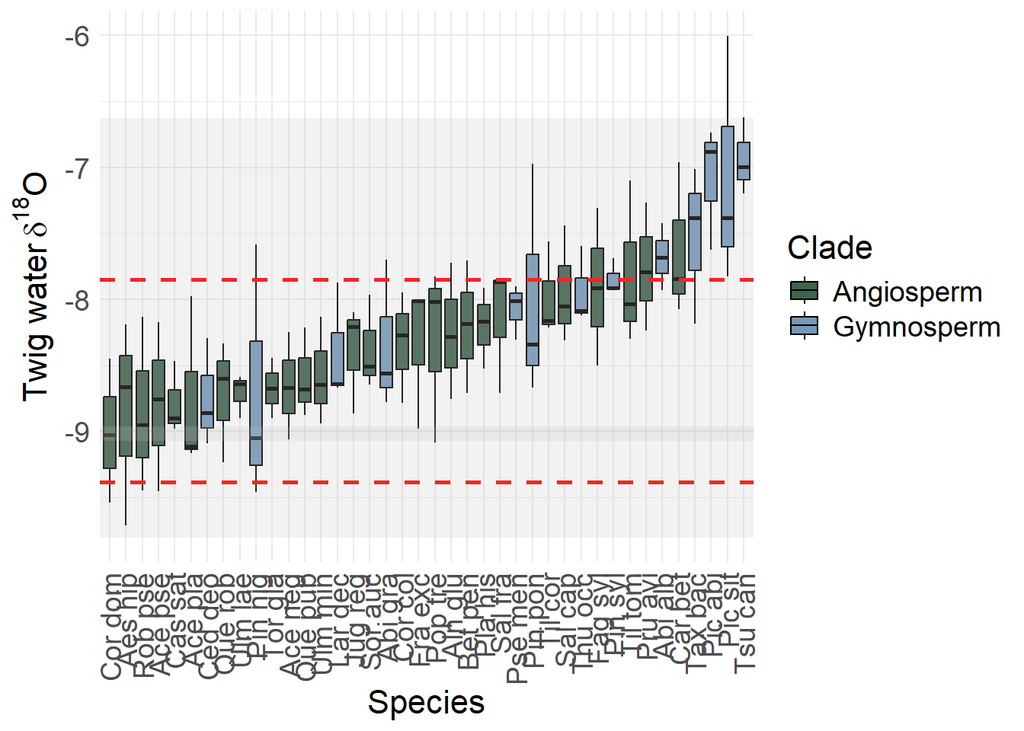

```r
stdv_10_20 <- soil_endmembers_3 %>%
  filter(depth %in% c(10, 20)) %>%
  summarise(stdv = sd(d18O, na.rm = TRUE)) %>%
  pull(stdv)

stdv_gt20 <- soil_endmembers_3 %>%
  filter(depth > 20) %>%
  summarise(stdv = sd(d18O, na.rm = TRUE)) %>%
  pull(stdv)

ggplot(twigs_mix_3,
       aes(x = fct_reorder(species_code, twig_d18O, .fun = mean),
           y = twig_d18O,
           fill = clade)) +
  geom_boxplot(color = "black") +

  # horizontal reference lines
  geom_hline(
    yintercept = mean_10_20,
    color = "red",
    linetype = "dashed",
    linewidth = 1
  ) +
  geom_hline(
    yintercept = mean_gt20,
    color = "red",
    linetype = "dashed",
    linewidth = 1
  ) +
# ± 1 SD around shallow soil mean
  annotate(
    "rect",
    xmin = -Inf,
    xmax = Inf,
    ymin = mean_10_20 - stdv_10_20,
    ymax = mean_10_20 + stdv_10_20,
    alpha = 0.2,
    fill = "grey"
  ) +

  # ± 1 SD around deep soil mean
  annotate(
    "rect",
    xmin = -Inf,
    xmax = Inf,
    ymin = mean_gt20 - stdv_gt20,
    ymax = mean_gt20 + stdv_gt20,
    alpha = 0.2,
    fill = "grey"
  ) +

  labs(
    x = "Species",
    y = expression("Twig water " * delta^18 * "O"),
    fill = "Clade"
  ) +

  scale_fill_manual(
    values = c(
      "A" = "#41624D",
      "G" = "#7798B9"
    ),
    labels = c(
      "A" = "Angiosperm",
      "G" = "Gymnosperm"
    )
  ) +

  theme_minimal() +
  theme(
    axis.title = element_text(size = 16),
    axis.text = element_text(size = 14),
    axis.text.x = element_text(
      angle = 90,
      vjust = 0.5,
      hjust = 1
    ),
    legend.title = element_text(size = 16),
    legend.text = element_text(size = 14)
  )
```

```r
#save figure in figures directory
ggsave(file.path(figs_dir, "Figure1.png"))
```

### Figure 2:

Plot showing the fraction of water taken up from the shallow layers (f<sub>shallow</sub>) of soil (20cm), by different tree individuals within the same species. Boxplots are ranked from highest to lowest species mean f<sub>shallow</sub>. Species are coloured according to their clade; angiosperms in green, and gymnosperms in blue.

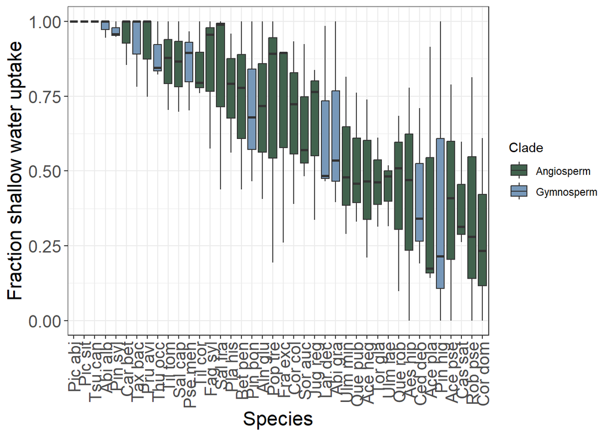

```r
##plot the fraction of water shallow sources for each tree, by species, coloured by clade
#plot, to have species in order of mean f_shallow, and colour by clade
twigs_mix_3 <- twigs_mix_3 %>%
  mutate(species_code = factor(
    species_code,
    levels = names(sort(tapply(f_shallow, species_code, mean), decreasing = TRUE))))

ggplot(twigs_mix_3, aes(y = f_shallow, x = species_code, fill = clade)) +
  geom_boxplot() +
  theme_bw() +
  labs(
    y = "Fraction shallow water uptake",
    x = "Species",
    fill = "Clade"   # Legend title
  ) +
  scale_fill_manual(
    values = c(
      "A" = "#41624D",
      "G" = "#7798B9"
    ),
    labels = c(
      "A" = "Angiosperm",
      "G" = "Gymnosperm"
    )
  ) +
  theme(
    axis.title = element_text(size = 16),
    axis.text = element_text(size = 14),
    axis.text.x = element_text(
      angle = 90,
      vjust = 0.5,
      hjust = 1
    )
  )
```

```r
#save figure in figures directory
ggsave(file.path(figs_dir, "Figure2.png"))
```

## Random Forest Model

### Aim and Structure:

A random forest regression model was used to identify the important mechanisms driving water uptake depth. The model had the following structure: f<sub>shallow</sub> ~ predicted root depth + sheltering index + LES position axis + growth resistance to drought + aridity tolerance index + maximum temperature tolerance index + soil moisture + drought tolerance + height + P50

#### Gap-filling Prior to the analysis

Missing values (6.2% of the original data) in the predictor variables were imputed using a random forest- based imputation approach implemented in the “missForest” function (Stekhoven & Bühlmann, 2012). Both the imputation and the subsequent RFM’s were run with 2500 trees. The imputation had up to 100 iterations, to ensure convergence and stability of imputed values. The resulting complete dataset was used for all subsequent analyses.

```r
library(missForest)
set.seed(123)

# Remove the taxonomic information
imp <- missForest(
  data[,-c(1,2,3,4,5,6,7)],
  maxiter=100,
  ntree=2500)
imputed_data <- imp$ximp

#Original data used for imputation (excluding species column)
data_variables<-data[,-c(1,2,3,4,5,6,7)]

# Calculate number and percentage of missing values
n_missing <- sum(is.na(data_variables))
n_total <- nrow(data_variables) * ncol(data_variables)

percent_missing <- (n_missing / n_total) * 100

percent_missing
```

```
## [1] 6.18793
```

### Figure 3:

Correlation matrix of global model predictor variables. Colours indicate the strength and direction of pairwise Spearman correlation coefficients, with blue representing positive correlations and red representing negative correlations. Correlation coefficient values are shown within each cell. Significance levels were indicated using asterisk notation based on p-values, where correlations with p < 0.05 were marked with one asterisk, p < 0.01 with two asterisks, and p < 0.001 with three asterisks. Non-significant correlations (p ≥ 0.05) were left unmarked.

[figure not shown]

```r
imputed_data2<- imputed_data %>%
  dplyr::select(-"f_shallow")
imputed_data_num <- imputed_data2[, sapply(imputed_data2, is.numeric)]

result <- corr.test(
  imputed_data_num,
  method = "spearman",
  use = "pairwise",
  adjust = "none"
)

cor_matrix <- result$r
p_matrix   <- result$p

new_names <- c(
  q10_aridity = "Aridity tolerance index",
  q90_max_T = "Max temperature tolerance",
  drought_tolerance_mean = "Drought tolerance",
  sheltering_index = "Sheltering index",
  mean_soil_moisture = "Mean soil moisture",
  pred_root_depth = "Predicted root depth",
  H_m = "Tree height",
  PC1_scores  = "slow-fast position (PC1)",
  growth_response_mean = "Growth resistance to drought",
  P50 = "Xylem vulnerability to embolism (P50)"
)

# rename rows and columns
rownames(cor_matrix) <- dplyr::recode(rownames(cor_matrix), !!!new_names)
colnames(cor_matrix) <- dplyr::recode(colnames(cor_matrix), !!!new_names)

rownames(p_matrix) <- rownames(cor_matrix)
colnames(p_matrix) <- colnames(cor_matrix)

df_cor <- reshape2::melt(cor_matrix)
df_p   <- reshape2::melt(p_matrix)

df <- cbind(df_cor, p = df_p$value)
colnames(df) <- c("Var1", "Var2", "r", "p")

df$stars <- ifelse(df$p < 0.001, "***",
                   ifelse(df$p < 0.01,  "**",
                          ifelse(df$p < 0.05,  "*", "")))


df$Var1 <- factor(df$Var1, levels = colnames(cor_matrix))
df$Var2 <- factor(df$Var2, levels = colnames(cor_matrix))

df <- df[as.numeric(df$Var1) < as.numeric(df$Var2), ]

ggplot(df, aes(x = Var1, y = Var2, fill = r)) +
  geom_tile() +
  geom_text(aes(label = sprintf("%.2f", r)), size = 5) +
  geom_text(aes(label = stars), color = "black", vjust = -0.8, size = 6) +
  scale_fill_gradient2(
    low = "#B2182B",
    mid = "white",
    high = "#2166AC",
    midpoint = 0
  ) +
  theme_classic(base_size = 16) +   # increases all base font sizes

  theme(
    axis.title = element_blank(),

    axis.text.x = element_text(
      angle = 45,
      hjust = 1,
      size = 14   # x-axis labels bigger
    ),

    axis.text.y = element_text(
      size = 14   # y-axis labels bigger
    ),

    panel.grid = element_blank()
  )
```

```r
result$p
```

```
##                                H_m  q10_aridity    q90_max_T
## H_m                    0.000000000 3.854683e-01 4.239016e-01
## q10_aridity            0.385468282 0.000000e+00 6.040227e-18
## q90_max_T              0.423901622 6.040227e-18 0.000000e+00
## drought_tolerance_mean 0.599519323 4.212434e-08 9.279085e-09
## sheltering_index       0.030890000 8.567545e-01 1.805100e-01
## pred_root_depth        0.052102330 9.455224e-01 3.888928e-01
## mean_soil_moisture     0.003153449 7.433672e-03 2.425228e-02
## growth_response_mean   0.241719460 2.432160e-01 1.271629e-01
## PC1_scores             0.203178706 2.092674e-01 2.419687e-01
## P50                    0.599032053 4.631040e-05 1.051370e-02
##                        drought_tolerance_mean sheltering_index pred_root_depth
## H_m                              5.995193e-01        0.0308900    5.210233e-02
## q10_aridity                      4.212434e-08        0.8567545    9.455224e-01
## q90_max_T                        9.279085e-09        0.1805100    3.888928e-01
## drought_tolerance_mean           0.000000e+00        0.2127493    2.067206e-01
## sheltering_index                 2.127493e-01        0.0000000    3.580145e-01
## pred_root_depth                  2.067206e-01        0.3580145    0.000000e+00
## mean_soil_moisture               7.064798e-02        0.3399232    5.387019e-02
## growth_response_mean             8.896677e-01        0.4167845    7.492443e-01
## PC1_scores                       9.671454e-01        0.9541066    8.466228e-03
## P50                              1.028848e-02        0.2275591    5.890108e-06
##                        mean_soil_moisture growth_response_mean   PC1_scores
## H_m                           0.003153449           0.24171946 2.031787e-01
## q10_aridity                   0.007433672           0.24321601 2.092674e-01
## q90_max_T                     0.024252283           0.12716290 2.419687e-01
## drought_tolerance_mean        0.070647983           0.88966773 9.671454e-01
## sheltering_index              0.339923162           0.41678447 9.541066e-01
## pred_root_depth               0.053870188           0.74924426 8.466228e-03
## mean_soil_moisture            0.000000000           0.16445904 1.004337e-01
## growth_response_mean          0.164459042           0.00000000 3.460302e-01
## PC1_scores                    0.100433742           0.34603022 0.000000e+00
## P50                           0.004143564           0.02849386 5.917026e-09
##                                 P50
## H_m                    5.990321e-01
## q10_aridity            4.631040e-05
## q90_max_T              1.051370e-02
## drought_tolerance_mean 1.028848e-02
## sheltering_index       2.275591e-01
## pred_root_depth        5.890108e-06
## mean_soil_moisture     4.143564e-03
## growth_response_mean   2.849386e-02
## PC1_scores             5.917026e-09
## P50                    0.000000e+00
```

### Finding the best-fit model

To identify a subset of predictors that best predict f<sub>shallow</sub>, a recursive feature elimination (RFE) procedure was implemented. Starting with the full set of predictors, variables were sequentially removed based on their importance, with the least important variable removed at each iteration. At each step, a new random forest model was fitted and model performance was evaluated using out-of-bag (OOB) estimates of the coefficient of determination (R²) and root mean squared error (RMSE). The optimal model was selected as the one with the highest R² value. This procedure resulted in a reduced predictor set of eight variables. A final random forest model was then fitted using only the selected set of optimal predictor variables.

```r
library(ranger)
rf_model <- ranger(
  f_shallow ~ .,
  data = imputed_data,
  importance = "permutation",
  num.trees = 2500,
  seed = 123
)

# find best-fit model
rf_data <- imputed_data

# Response variable
response <- "f_shallow"

# Predictor variables
predictors <- setdiff(names(rf_data), response)
current_vars <- predictors

# storage objects
results <- data.frame(
  n_variables = integer(),
  removed_variable = character(),
  R2 = numeric(),
  RMSE = numeric(),
  variables = I(list())
)

# recursive feature elimination
while(length(current_vars) > 1) {

  cat("Running model with", length(current_vars), "variables\n")

  # Build formula
  rf_formula <- as.formula(
    paste(response, "~", paste(current_vars, collapse = "+"))
  )

  # Fit random forest
  rf <- ranger(
    formula = rf_formula,
    data = rf_data,
    importance = "permutation",
    num.trees = 2500,
    seed = 123,
    oob.error = TRUE
  )

  # Extract performance
  r2 <- 1 - rf$prediction.error / var(rf_data[[response]])
  rmse <- sqrt(rf$prediction.error)
  # Variable importance
  importance <- sort(rf$variable.importance)

  # Variable to remove
  remove_var <- names(importance)[1]

  # Store results (FIXED: store full variable set safely)
  results <- rbind(
    results,
    data.frame(
      n_variables = length(current_vars),
      removed_variable = remove_var,
      R2 = r2,
      RMSE = rmse,
      variables = I(list(current_vars))   # <- stores list, not string
    )
  )

  # Update variables
  current_vars <- setdiff(current_vars, remove_var)
}
```

```
## Running model with 10 variables
## Running model with 9 variables
## Running model with 8 variables
## Running model with 7 variables
## Running model with 6 variables
## Running model with 5 variables
## Running model with 4 variables
## Running model with 3 variables
## Running model with 2 variables
```

```r
# find best model
best_row <- results[which.max(results$R2), ]
best_row
```

```
##   n_variables removed_variable        R2      RMSE    variables
## 3           8              H_m 0.2025911 0.2729778 H_m, q10....
```

```r
# extract predictors
best_predictors <- best_row$variables[[1]]
best_predictors
```

```
## [1] "H_m"                    "q10_aridity"            "q90_max_T"
## [4] "drought_tolerance_mean" "sheltering_index"       "growth_response_mean"
## [7] "PC1_scores"             "P50"
```

```r
# fit final model
final_rf <- ranger(
  f_shallow ~ .,
  data = rf_data[, c("f_shallow", best_predictors)],
  importance = "permutation",
  num.trees = 2500,
  seed = 123
)

final_rf
```

```
## Ranger result
##
## Call:
##  ranger(f_shallow ~ ., data = rf_data[, c("f_shallow", best_predictors)],      importance = "permutation", num.trees = 2500, seed = 123)
##
## Type:                             Regression
## Number of trees:                  2500
## Sample size:                      119
## Number of independent variables:  8
## Mtry:                             2
## Target node size:                 5
## Variable importance mode:         permutation
## Splitrule:                        variance
## OOB prediction error (MSE):       0.07451686
## R squared (OOB):                  0.2025911
```

```r
#R2 (OOB)= 0.2; OOB predicted error (MSE) = 0.07
```

To identify the relative contribution of predictor variables to the variation in f<sub>shallow</sub> and the statistical significance of the variable importance, we applied a random forest regression approach with the best-fit model using the “rfPermute” package (Archer, 2025) and 1000 permutations of the response variable.

```r
# use rfpermute to get p-values for variable importance
library(rfPermute)
rfp <- rfPermute::rfPermute(
  f_shallow ~ .,
  data = rf_data[, c("f_shallow", best_predictors)],
  ntree = 2500,
  num.rep = 1000
)
```

### Table 1:

Variable importance from the random forest model predicting f<sub>shallow</sub> (fraction of shallow water uptake), based on permutation importance (%IncMSE) and associated significance values derived from 1000 permutations. Higher %IncMSE values indicate greater importance of a predictor in reducing model accuracy when permuted

```r
#Extract importance values
rf_importance <- as.data.frame(rfPermute::importance(rfp))
# Add predictor names as a column
rf_importance$Predictor <- rownames(rf_importance)
# Reorder columns
rf_importance <- rf_importance[, c("Predictor", setdiff(names(rf_importance), "Predictor"))]
# Sort by %IncMSE (highest to lowest)
rf_importance <- rf_importance[order(-rf_importance$`%IncMSE`), ]
# Reset row names
rownames(rf_importance) <- NULL
# View result
rf_importance
```

```
##                Predictor  %IncMSE %IncMSE.pval IncNodePurity IncNodePurity.pval
## 1            q10_aridity 29.46154  0.000999001     1.1702486        0.045954046
## 2 drought_tolerance_mean 24.80579  0.006993007     1.4913192        0.002997003
## 3       sheltering_index 23.17587  0.006993007     1.6105414        0.326673327
## 4                    P50 20.42066  0.011988012     1.0062887        0.454545455
## 5              q90_max_T 19.59816  0.012987013     0.9653545        0.185814186
## 6             PC1_scores 15.80342  0.019980020     0.9185694        0.612387612
## 7   growth_response_mean 13.59534  0.044955045     1.3705055        0.931068931
## 8                    H_m 12.65312  0.057942058     1.1943315        0.974025974
```

```r
#export rf_importance
write.csv(rf_importance, file.path(tabs_dir,"Table1.csv"))
```

### Figure 4:

Partial dependence plots (PDPs) showing the marginal effect of each predictor on the model’s predicted response (f<sub>shallow</sub>), while averaging over all other variables in the random forest. Each panel represents a single predictor, with the x-axis showing the observed range of that variable and the y-axis showing the corresponding change in predicted f<sub>shallow</sub>. For a) the unit was multiplied by ten thousand for visualisation. These plots illustrate potential non-linear relationships and the direction and strength of each predictor’s influence on the model output.

[figure not shown]

```r
predictor_vars <- best_predictors
data <- rf_data[, c("f_shallow", predictor_vars)]

label_map <- c(
  "q10_aridity" = "a) Aridity tolerance index",
  "drought_tolerance_mean" = "b) Drought tolerance",
  "sheltering_index" = "c) Sheltering index",
  "P50"= "d)  P50",
  "q90_max_T" = "e) Max Temp tolerance",
  "PC1_scores" = "f) Slow-fast position (PC1)",
  "growth_response_mean" = "g) Growth resistance",
  "H_m" = "h) Tree height"
)
pdp_list <- lapply(predictor_vars, function(x) {

  pd <- pdp::partial(
    object = final_rf,
    pred.var = x,
    train = data,
    grid.resolution = 50,
    ice = FALSE,
    select = TRUE
  )

  names(pd)[1] <- "x"   # standardise x column

  pd$variable <- x
  pd
})

pdp_data <- bind_rows(pdp_list)

pdp_data$variable_label <- factor(
  label_map[pdp_data$variable],
  levels = unique(label_map)
)

pdp_data$x[pdp_data$variable == "q10_aridity"] <-
  pdp_data$x[pdp_data$variable == "q10_aridity"] * 10000

ggplot(pdp_data, aes(x = x, y = yhat)) +
  geom_line(linewidth = 1) +
  facet_wrap(~variable_label, scales = "free_x", ncol = 2) +
  theme_bw(base_size = 12) +
  labs(
    x = "Predictor value",
    y = expression("Predicted " * f[shallow])
  ) +
  theme(
    aspect.ratio = 0.6,
    axis.title = element_text(size = 16),
    axis.text = element_text(size = 12),
    strip.text = element_text(size = 14),
    axis.title.x = element_text(
      margin = ggplot2::margin(t = 10)
    ),
    plot.margin = ggplot2::margin(10, 15, 10, 10)
  )
```

```r
ggsave(file.path(figs_dir, "Figure4.png"))
```

### Figure 5:

2D Partial Dependence Plots (PDPs) visualizing the marginal effect two predictors have on the predicted outcome of the model (f<sub>shallow</sub>). This plot looks specifically at possible interactions between a) drought tolerance and aridity tolerance index, b) drought tolerance and sheltering index, c) growth resistance to drought and sheltering index and d) drought tolerance and height.

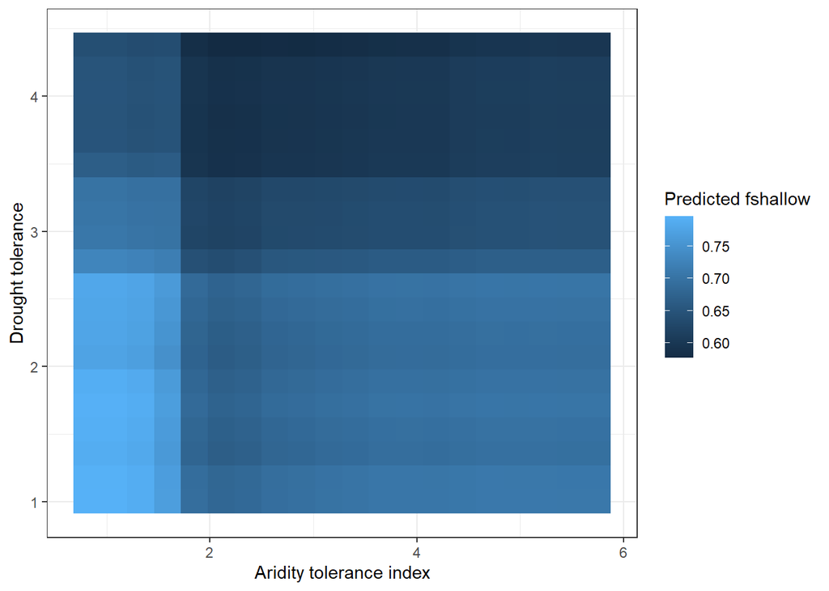

```r
X <- rf_data[, best_predictors]
y <- rf_data$f_shallow

predictor <- Predictor$new(
  final_rf,
  data = X,
  y = y,
  predict.function = function(model, newdata) {
    predict(model, data = newdata)$predictions
  }
)
# a)drought tolerance and q10 aridity
pdp1 <- FeatureEffect$new(
  predictor,
  feature = c("q10_aridity", "drought_tolerance_mean"),
  method = "pdp"
)

df <- pdp1$results
ggplot(df, aes(
  x = q10_aridity*10000,
  y = drought_tolerance_mean,
  fill = .value
)) +
  geom_tile() +
  theme_bw() +
  labs(
    x = "Aridity tolerance index",
    y = "Drought tolerance",
    fill = "Predicted fshallow"
  )
```

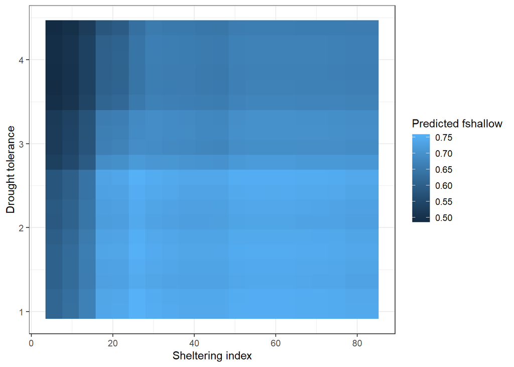

```r
ggsave(file.path(figs_dir, "Figure4a.png"))
# b) sheltering index and drought tolerance
pdp2 <- FeatureEffect$new(
  predictor,
  feature = c("sheltering_index", "drought_tolerance_mean"),
  method = "pdp"
)

df <- pdp2$results
ggplot(df, aes(
  x = sheltering_index,
  y = drought_tolerance_mean,
  fill = .value
)) +
  geom_tile() +
  theme_bw() +
  labs(
    x = "Sheltering index",
    y = "Drought tolerance",
    fill = "Predicted fshallow"
  )
```

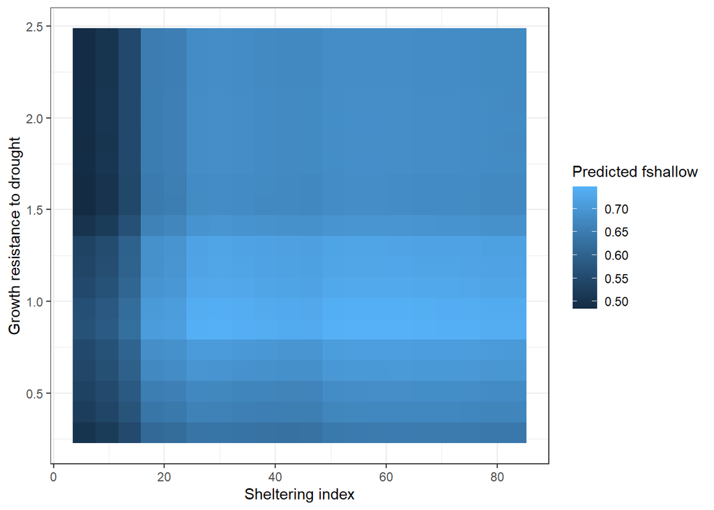

```r
ggsave(file.path(figs_dir, "Figure4b.png"))
# c) sheltering index and growth response
pdp3 <- FeatureEffect$new(
  predictor,
  feature = c("sheltering_index", "growth_response_mean"),
  method = "pdp"
)

df <- pdp3$results
ggplot(df, aes(
  x = sheltering_index,
  y = growth_response_mean,
  fill = .value
)) +
  geom_tile() +
  theme_bw() +
  labs(
    x = "Sheltering index",
    y = "Growth resistance to drought",
    fill = "Predicted fshallow"
  )
```

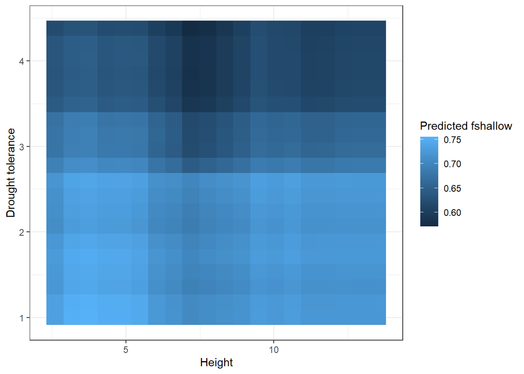

```r
ggsave(file.path(figs_dir, "Figure4c.png"))
# d) Height and drought tolerance
pdp4 <- FeatureEffect$new(
  predictor,
  feature = c("H_m", "drought_tolerance_mean"),
  method = "pdp"
)

df <- pdp4$results
ggplot(df, aes(
  x = H_m,
  y = drought_tolerance_mean,
  fill = .value
)) +
  geom_tile() +
  theme_bw() +
  labs(
    x = "Height",
    y = "Drought tolerance",
    fill = "Predicted fshallow"
  )
```

```r
ggsave(file.path(figs_dir, "Figure4d.png"))
```

# Supplementary Appendices

### Figure A1

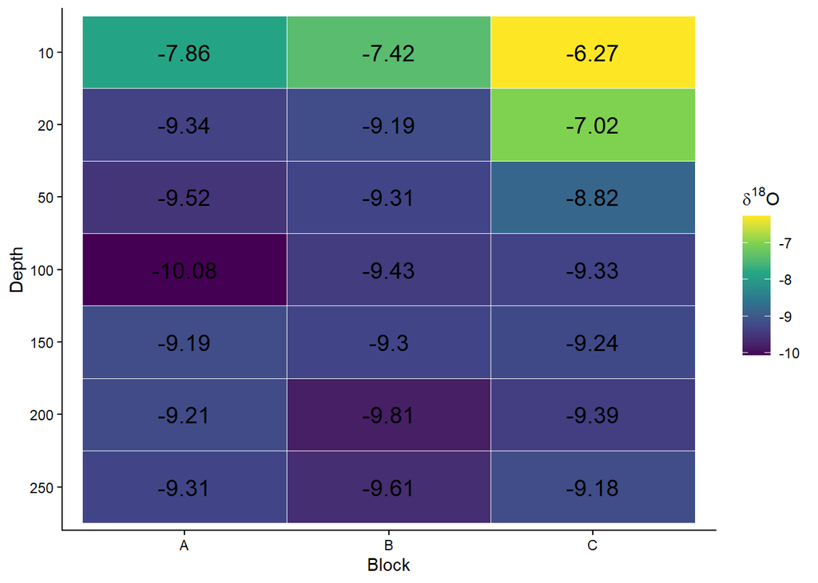

```r
mean_d18O <- soil_endmembers_3 %>%
  group_by(block, depth) %>%
  summarise(
    mean_d18O = mean(d18O, na.rm = TRUE),
    .groups = "drop"
  )

ggplot(data = mean_d18O,
       aes(x = block,
           y = factor(depth, levels = rev(unique(depth))),
           fill = mean_d18O)) +
  geom_tile(color = "white") +
  geom_text(aes(label = round(mean_d18O, 2)),
            color = "black",
            size = 5) +
  scale_fill_viridis_c(name = expression(delta^18*O)) +
  labs(x = "Block", y = "Depth") +
  theme_classic()
```

```r
ggsave(file.path(suppl_dir, "Figure_A1.png"))
```

### Figure A3

```r
#upload categorical root data  - classifications according to ATLAS
#root types: 1= shallow, 2= intermediate, 3= deep
root_types <- read.csv(file.path(prelim_dir, "root_category.csv"))
#remove NAs
root_types <- root_types %>%
  filter(!is.na(root_category))
#add root types to pred_10, by species
root_var <- root_data %>%
  left_join(root_types, by = "species")
#select only complete cases
root_var <- root_var %>%
  filter(!is.na(root_category))
#correlation test between predicted root depth at 10 cm height and root category (1,2,3)
cor.test(root_var$pred, root_var$root_category, method = "spearman")
```

```
##
##  Spearman's rank correlation rho
##
## data:  root_var$pred and root_var$root_category
## S = 1844.3, p-value = 0.002198
## alternative hypothesis: true rho is not equal to 0
## sample estimates:
##       rho
## 0.5457274
```

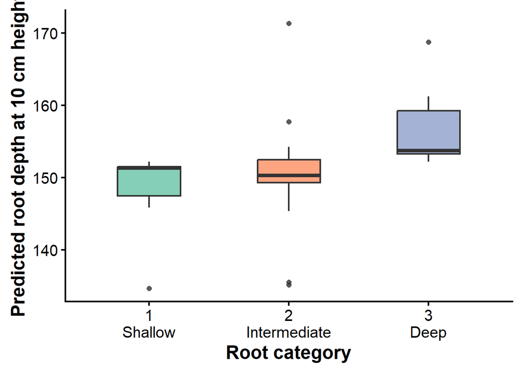

```r
#plot predicted root depth at 10 cm height vs root category, by species
ggplot(root_var, aes(x = factor(root_category),
                     y = pred_root_depth,
                     fill = factor(root_category))) +
  geom_boxplot(width = 0.45,
               linewidth = 0.8,
               outlier.size = 2,
               alpha = 0.8) +
  scale_fill_brewer(palette = "Set2", guide = "none") +
  labs(
    x = "Root category",
    y = "Predicted root depth at 10 cm height"
  ) +
  scale_x_discrete(labels = c("1\nShallow",
                              "2\nIntermediate",
                              "3\nDeep")) +
  theme_classic(base_size = 16) +
  theme(
    axis.title = element_text(size = 18, face = "bold"),
    axis.text = element_text(size = 15),
    axis.line = element_line(linewidth = 0.8),
    plot.margin = margin(10, 10, 10, 10)
  )
```

```r
#save figure in supplementary directory
ggsave(file.path(suppl_dir, "Figure_A3.png"))
```

### Figure A4 and Figure A5

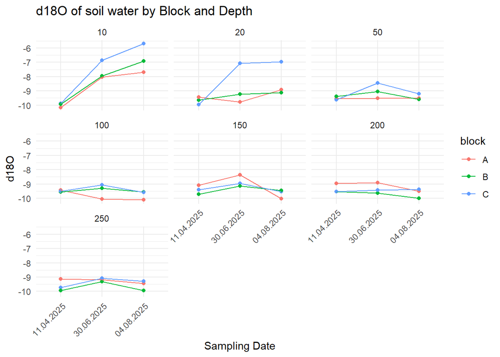

```r
soil <- read.csv(file.path(prelim_dir, "d18O_extracted_water_soil.csv"))
twigs <- read.csv(file.path(prelim_dir, "d18O_extracted_water_twigs.csv"))

#plot d18O of different block, depth, over the 3 different dates. include line connecting points of the same block and depth
# Change order of sampling date on x axis
soil$`sampling_date` <- factor(soil$`sampling_date`, levels = c("11.04.2025", "30.06.2025", "04.08.2025"))
ggplot(soil, aes(x =`sampling_date`, y = d18O, color = block, group = interaction(block, depth))) +
  geom_point() +
  geom_line() +
  facet_wrap(~ depth) +
  labs(title = "d18O of soil water by Block and Depth", x = "Sampling Date", y = "d18O") +
  theme_minimal() +
  theme(axis.text.x = element_text(angle = 45, hjust = 1))
```

```r
# save image to supplementary directory
ggsave(file.path(suppl_dir, "Figure_A5.png"))
# Average soil d18O per depth, location and date
soil_summary <- soil %>%
  group_by(sampling_date, block, depth) %>%
  summarise(
    mean_d18O = mean(d18O, na.rm = TRUE)
  )
```

```
## `summarise()` has regrouped the output.
## ℹ Summaries were computed grouped by sampling_date, block, and depth.
## ℹ Output is grouped by sampling_date and block.
## ℹ Use `summarise(.groups = "drop_last")` to silence this message.
## ℹ Use `summarise(.by = c(sampling_date, block, depth))` for per-operation
##   grouping (`?dplyr::dplyr_by`) instead.
```

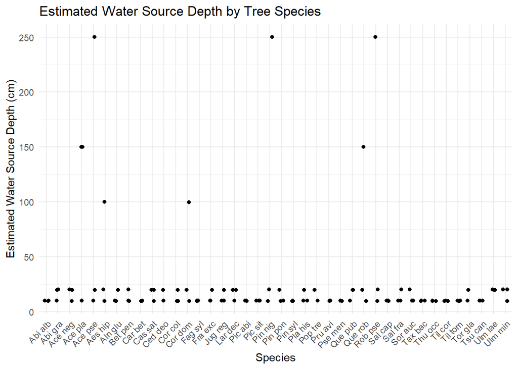

```r
# Calculate average soil d18O per depth, across all blocks and dates
soil_avg <- soil %>%
  group_by(depth) %>%
  summarize(mean_d18O = mean(d18O, na.rm = TRUE))

# Export soil_avg as table
write.csv(soil_avg, file.path(suppl_dir, "soil_avg_d18O_by_depth.csv"), row.names = FALSE)

# Soil depth from which tree most likely gets its water (based on d18O)
twigs$ID<-paste(twigs$block, twigs$species_code, sep = "_")
twig_sources <- expand.grid(ID = twigs$ID,
                            depth = soil_avg$depth)
# Join twig δ18O
twig_sources <- twig_sources %>%
  left_join(twigs, by = "ID") %>%
  left_join(soil_avg, by = "depth") %>%
  mutate(diff = abs(d18O - mean_d18O))

# Find depth with minimum difference per tree
best_depth <- twig_sources %>%
  group_by(ID) %>%
  slice_min(diff, n = 1) %>%
  select(ID, species_code, depth, d18O, mean_d18O, diff)
# Remove NAs
best_depth <- best_depth[!is.na(best_depth$d18O) & !is.na(best_depth$mean_d18O), ]

# Create plot
ggplot(best_depth, aes(x = species_code, y = depth)) +
  geom_jitter(width = 0.2, height = 0.2) +
  labs(title = "Estimated Water Source Depth by Tree Species", x = "Species", y = "Estimated Water Source Depth (cm)") +
  theme_minimal() +
  theme(axis.text.x = element_text(angle = 45, hjust = 1))
```

```r
# shows that most individuals are getting their water from 10, 20 cm depths
# only 8 individuals outside this range, which get their water at depths of 100-250 (or more?) cm
ggsave(file.path(suppl_dir, "Figure_A4.png"))
```

### Figure A6

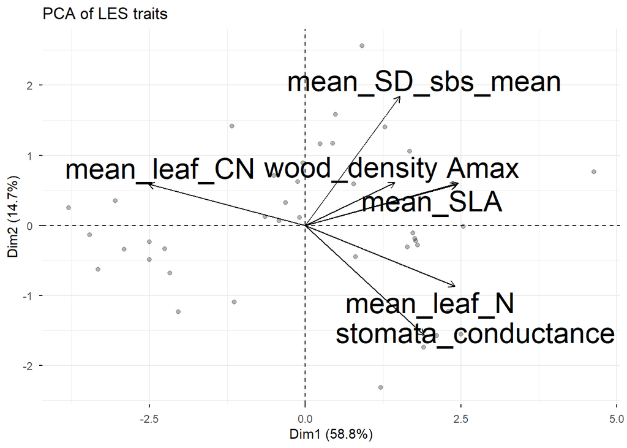

```r
pca<-prcomp(imputed_data_LES[,c("mean_SLA", "mean_leaf_N", "mean_leaf_CN", "mean_SD_sbs_mean", "Amax", "stomata_conductance", "wood_density")], center = TRUE, scale. = TRUE)

fviz_pca_biplot(pca,
                repel = TRUE,
                geom.ind = "point",
                alpha.ind = 0.3,
                label = "var",
                labelsize = 8,
                col.var = "black",
                title = "PCA of LES traits")
```

### Figure A7

Interaction strength of random forest model variables

```r
renv::install("rstudioapi")
```

[output not shown]

```r
library(rstudioapi)
interaction <- Interaction$new(predictor)
```

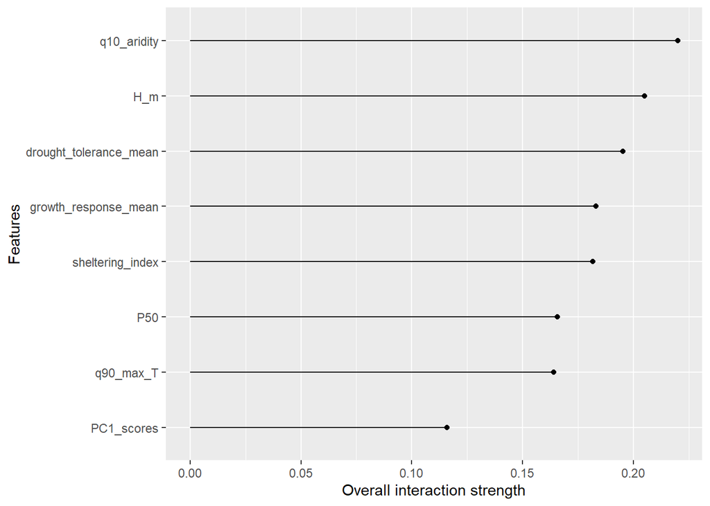

```r
plot(interaction)
```

```r
interaction_results <- interaction$results
ggsave(file.path(suppl_dir, "FigureA7.png"))
```